# A short introduction into Metropolis & Metropolis Hastings

Metropolis is a very general and intuitive sampling algorithm. In this report, we will take a look at how to implement a simple Metropolis sampler and also how to implement its' common extension: the Metropolis-Hastings algorithm.

Before we get started, we will set up some required libraries and convenient plotting function for visualizing our sampling algorithms.

```python
import numpy as np
import scipy.stats as stats
import matplotlib.pyplot as plt
import seaborn as sns
from itertools import islice
from mpl_toolkits.mplot3d import Axes3D
from matplotlib import cm
from matplotlib.ticker import LinearLocator, FormatStrFormatter
#import plotly.plotly as py
import plotly.offline as py
import plotly.graph_objs as go
from plotly import __version__
from plotly.offline import download_plotlyjs, init_notebook_mode, plot, iplot

%matplotlib inline
#set plotly to notebook mode
init_notebook_mode(connected=True)

#shameless copy/paste


def plotfun(f,frm,to):
    fig = plt.figure()
    ax = fig.gca(projection='3d')
    X = np.arange(frm[0], to[0], 0.05)
    Y = np.arange(frm[1], to[1], 0.05)
    X, Y = np.meshgrid(X, Y)
    Z=np.vectorize(L)(X,Y)
    surf = ax.plot_surface(X, Y, Z, rstride=1, cstride=1, cmap=cm.coolwarm,
                           linewidth=0, antialiased=False)
    #ax.set_zlim(-0.5, 1000)
    ax.zaxis.set_major_locator(LinearLocator(10))
    ax.zaxis.set_major_formatter(FormatStrFormatter('%.02f'))
    fig.colorbar(surf, shrink=0.5, aspect=5)
    plt.show()

def plotpts(pts,L):
    fig = plt.figure()
    ax = fig.gca(projection='3d')
    pts = np.array(pts)
    X = pts[:,0]
    Y = pts[:,1]
    Z=np.vectorize(L)(X,Y)
    surf = ax.scatter(X, Y, Z, cmap=cm.coolwarm)
    ax.zaxis.set_major_locator(LinearLocator(10))
    ax.zaxis.set_major_formatter(FormatStrFormatter('%.02f'))
    plt.show()


#plots a 2d histogram from a 2D points collection
def hist2d(pnts):
    pnts_ar = np.array(pnts)
    sns.jointplot(pnts_ar[:,0],pnts_ar[:,1], kind='scatter');
    plt.hist(pnts_ar,50,normed=True)
    plt.show()
    plt.plot(pnts)
    plt.show()

def trace3d_ly(pts,f,title='Egg Box Sampling'):
    X,Y,Z=pts[:,0],pts[:,1],np.array([f(*pt) for pt in pts])
    trace = go.Scatter3d(x=X, y=Y, z=Z,
        marker=dict(size=4,color=Z,colorscale='Viridis',),
            line=dict(color='#1f77b4',width=1))
    data = [trace]
    layout = dict(
        width=800,
        height=700,
        autosize=False,
        title=title,
        scene=dict(
            xaxis=dict(
                gridcolor='rgb(255, 255, 255)',
                zerolinecolor='rgb(255, 255, 255)',
                showbackground=True,
                backgroundcolor='rgb(230, 230,230)'
            ),
            yaxis=dict(
                gridcolor='rgb(255, 255, 255)',
                zerolinecolor='rgb(255, 255, 255)',
                showbackground=True,
                backgroundcolor='rgb(230, 230,230)'
            ),
            zaxis=dict(
                gridcolor='rgb(255, 255, 255)',
                zerolinecolor='rgb(255, 255, 255)',
                showbackground=True,
                backgroundcolor='rgb(230, 230,230)'
            ),
            camera=dict(
                up=dict(
                    x=0,
                    y=0,
                    z=1
                ),
                eye=dict(
                    x=-1.7428,
                    y=1.0707,
                    z=0.7100,
                )
            ),
            aspectratio = dict( x=1, y=1, z=0.7 ),
            aspectmode = 'manual'
        ),
    )
    fig = dict(data=data, layout=layout)
    #return py.iplot(fig, filename=title, height=700, validate=False)
    return py.iplot(fig, filename=title, validate=False)
```

## Introducing iterate into python

In functional programming languages such as Haskell or Clojure, we have the common concept of an *iterate* higher order function.

```python
def iterate(f,x):
    while 1:
        yield x
        x=f(x)

def rep(f):
    return (f() for i in iter(int,1))
```

## Implementing the Metropolis Iteration function

What actually differentiates the Metropolis algorithm from other variants is the actual iteration function. In this function, we determine a proposal and decide if we accept the new sample or keep the old one.

But for other algorithms, we could simply replace the iteration function.

```python
# f: proportial to density, p: proposal, i: previous/initial value
def iteration(f,p,i):
        x = p(i)
        return x if f(x)/f(i) > np.random.uniform() else i

def sample(f,p,i,n):
    iteratee = lambda i: iteration(f,p,i)
    return islice(iterate(iteratee,i),0,n)
```

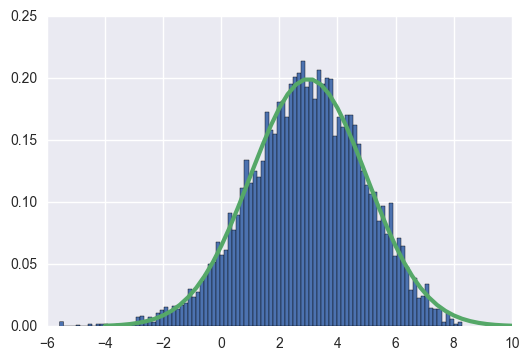

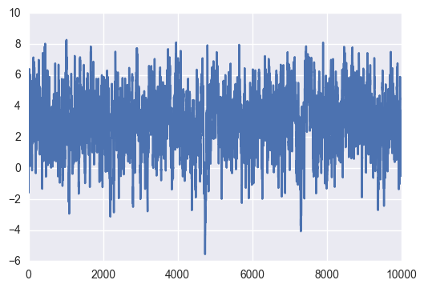

```python
# target distribution, multiplied by 4
f = lambda x: 4*stats.norm.pdf(x,loc=3,scale=2)

#arbitrary jump distr. + initial values
initial = 1
p=np.random.normal

#
pnts = list(sample(f,p,initial,10000))

#plot
plt.hist(pnts,100,normed=True)
x=np.linspace(-4,10)
plt.plot(x,f(x)/4,lw=3)
plt.show()

plt.plot(pnts)
plt.show()
```

# A 2D Example

Metropolis Hastings can also be used for multivariate distributions. In this case, we need a jump distribution that generates multiple values at once.

```python
# f: proportial to density, p: proposal, i: previous/initial value

def iterate_m(f,*x):
    while 1:
        yield x
        x=f(*x)


def iteration_m(f,p,i):
        x = p(*i)
        return x if f(*x)/f(*i) > np.random.uniform() else i


def sample_m(f,p,i,n):
    iteratee = lambda i: iteration_m(f,p,i)
    return islice(iterate(iteratee,i),0,n)
```

```python
#model
def p_x(x):
    return stats.uniform.pdf(x,0.5,1.5)

def p_y_x(y,x):
    return stats.norm.pdf(y,x,1)

def p_xy(y,x):
    return p_y_x(y,x)*p_x(x)
```

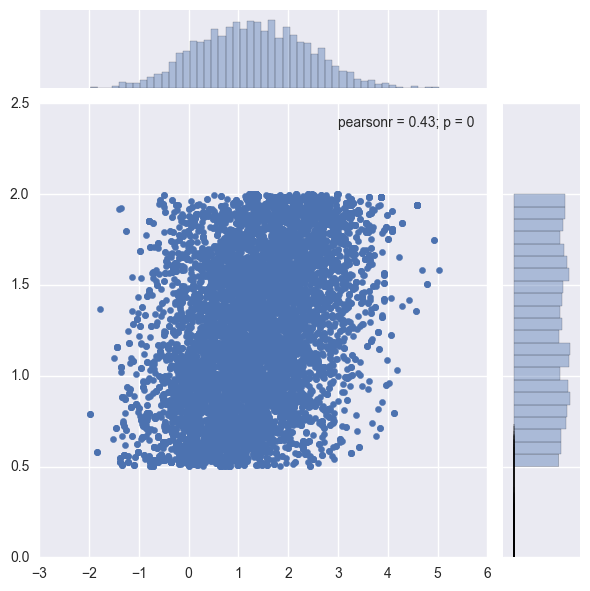

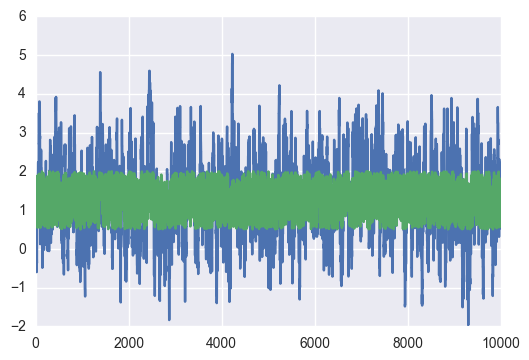

[interactive chart not shown]

```python
#arbitrary jump distr. + initial values
initial = (1,1)
p=lambda y,x: (np.random.normal(y,0.5),np.random.normal(x,0.5))

pnts = list(sample_m(p_xy,p,initial,10000))

hist2d(pnts)
trace3d_ly(np.array(pnts)[::10],p_xy,title="uniform prior, normal likelihood")
```

## Gaussian Shells

```python
# gaussian shells
def l_gs(theta,c,r,w):
  return sum(circle(theta,c[i],r[i],w[i]) for i in (0,1))

def circle(theta,c,r,w):
    return np.exp( -(np.linalg.norm(theta-c)-r)**2/(2*w**2))/(2*np.pi*w**2)

#model
w=[0.1,0.1]
r=[2,2]
#c1 and c2 are 7 units apart. priors on -6 to 6, with allowed error
error = 0.2
c= next(prop for prop in rep(lambda:[np.random.uniform(-6,6,2) for k in (0,1)])
                            if np.abs(np.linalg.norm(prop[0]-prop[1])-7)<error)

def L_gs(a,b):
    return l([a,b],c,r,w)
```

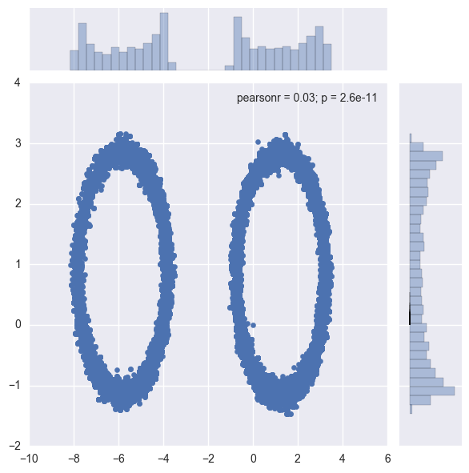

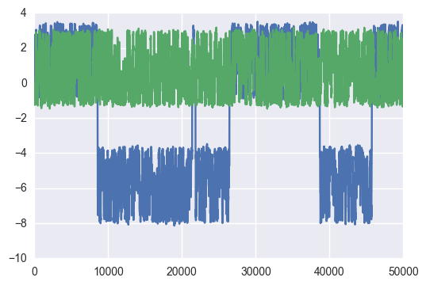

[interactive chart not shown]

```python
#arbitrary jump distr. + initial values
initial = (0,0)
p=lambda y,x: (np.random.normal(y,1),np.random.normal(x,1))

pnts = list(sample_m(L,p,initial,50000))

hist2d(pnts)
trace3d_ly(np.array(pnts)[::10],L_gs,title="Gaussian Shells, Metropolis")
```

### Egg box model

We take a look at an egg-box model.

```python
def l_egg(x,y):
    return np.exp((2+np.cos(x/2)*np.cos(y/2))**5)

#uniform prior 0..10*pi for x and y
frm_egg = [0,0]
to_egg = [10*np.pi, 10*np.pi]

def prior_egg(*pt):
    return 1*(all(np.greater(pt,frm_egg)) and all(np.less(pt, np.array(to_egg))))

def l_p_egg(x,y):
    return prior_egg(x,y)*l_egg(x,y)
```

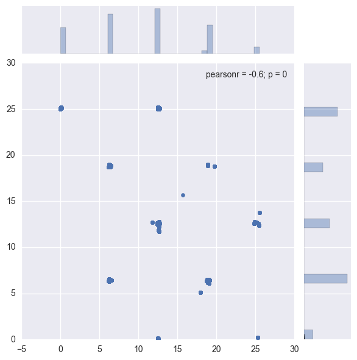

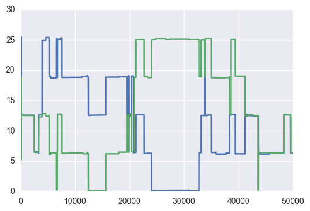

[interactive chart not shown]

```python
#arbitrary jump distr. + initial values
initial = (5*np.pi,5*np.pi)
p=lambda y,x: (np.random.normal(y,5),np.random.normal(x,5))

pnts = list(sample_m(l_p_egg,p,initial,50000))

hist2d(pnts)
trace3d_ly(np.array(pnts)[::10],lambda x,y: np.log(l_p_egg(x,y)),title="Egg-Box, Metropolis")
```

## Metropolis Hastings

The Metropolis Hastings algorithm is a more general form of the Metropolis Algorithm. It changes the algorithm, so that it also works with asymmetric Jump Distributions. The only requirement is that densities for the jump distributions can be computed. During the sampling process, we no longer only look at the ratio of densities, but at the ratio of densities from the target distribution *normalized* with the densities we have from the jump distribution. So when comparing densities, we now take the density into account, with which the sample has been generated (density of the jump distribution).

The new ratio computes as follows: $$r = \frac{p(\theta^*|y)/J_t(\theta^*|\theta^{t-1})}{p(\theta^{t-1}|y)/J_t(\theta^{t-1}|\theta^*)}$$

```python
# f: proportial to density, p: proposal, i: previous/initial value,
# j: proportional to density of jump distribution, takes 2* the parameters
def iteration_mh(f,p,i,j):
        x = p(*i)
        return x if (f(*x)/j(*(x+i)) )/(f(*i)/j(*(i+x)) ) > np.random.uniform() else i


def sample_mh(f,p,i,n,j):
    for k in range(n):
        i=iteration_mh(f,p,i,j)
        yield i
```

### Gaussian Shell Example with Metropolis Hastings

Now with metropolis hastings:

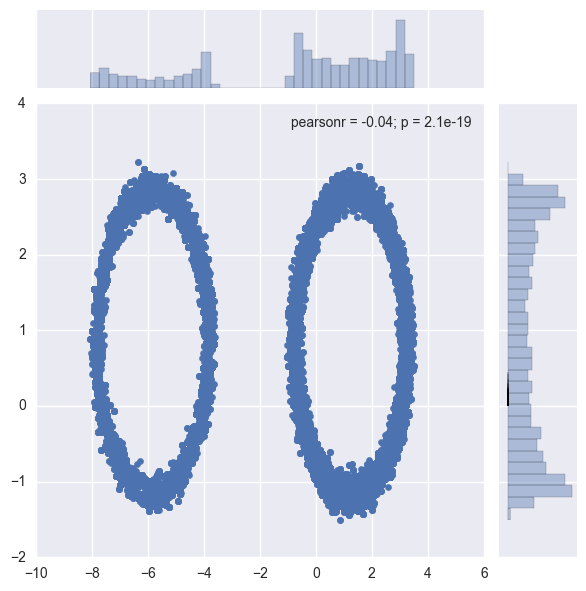

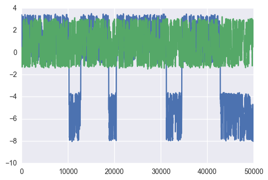

[interactive chart not shown]

```python
#arbitrary jump distr. + initial values
initial = (0,0)
p=lambda y,x: (np.random.normal(y,1),np.random.normal(x,1))
j=lambda y,x,y_p,x_p: stats.norm.pdf(y,y_p,1)*stats.norm.pdf(x,x_p,1)
pnts = list(sample_mh(L,p,initial,50000,j))

hist2d(pnts)
trace3d_ly(np.array(pnts)[::10],L, title="Gaussian Shells, Metropolis-Hastings")
```

### Egg Box Example with Metropolis-Hastings

Let's see if metropolis hastings can handle the egg box model better:

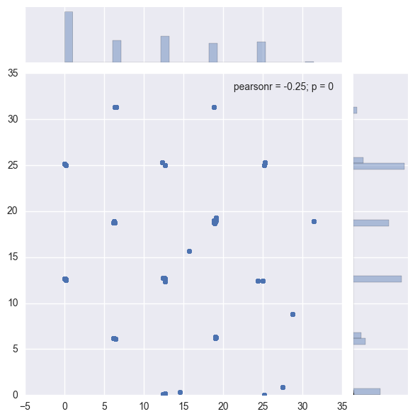

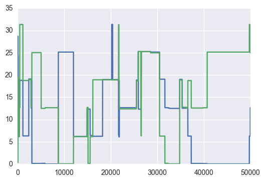

[interactive chart not shown]

```python
#arbitrary jump distr. + initial values
initial = (5*np.pi,5*np.pi)
p=lambda y,x: (np.random.normal(y,10),np.random.normal(x,10))
j=lambda y,x,y_p,x_p: stats.norm.pdf(y,y_p,10)*stats.norm.pdf(x,x_p,10)
pnts = list(sample_mh(l_p_egg,p,initial,50000,j))

hist2d(pnts)
trace3d_ly(np.array(pnts)[::10],lambda x,y: np.log(l_p_egg(x,y)),title="Egg-Box, Metropolis-Hastings")
```

Now this looks much better than pure metropolis. However, we might have to try different model parameters for a true comparison.

# Future Ideas

More general MH version with lodash like functions?

Use keyword arguments!

Use objects with the same keywords for distributions!

Allow Arrays for multiple distributions?

How do we handle keywords?

Or just use functions that take theta as input? this might make things easier, but also harder

Interactive setting of hyperparameters?

#### Proposal: Use kwargs for dealing with arguments.

benefits: we can use parameter names in our functions downside: might lead to ambiguity, when we pass multiple keyword parameters